# Gentle Introduction to R Shiny

Clinton

2021-06-08

Shiny is an R framework that makes it easy to develop web applications without necessarily knowing HTML. The skill will come in handy in situations where you want to share your R model to people as an interactive dashboard or maybe perform an exploratory data analysis that has interactive visualizations on it and many other use cases.

[figure not shown]

```r
knitr::opts_chunk$set(echo = TRUE, warning = FALSE,message = FALSE)
```

*fig1: The screenshot above is for a simple shiny app.*

# What’s so shiny about Shiny?

- With Shiny you are able to share analysis results in form of interactive graphics and tables.
- With Shiny you can customize your application to your liking.
- It has an active and rich community.

Good, with that in mind let’s now dive into the steps guiding us in the development process.

# Installation and loading of libraries

We’ll need the following libraries as we proceed, install (in case you hadn’t) and load them.

> Some tip! to install a package use: *install.packages(“packagename”)* to load a package use: *library(packagename)*.

```r
#install.packages("shiny")
#install.packages("dplyr")
#install.packages("data.table)
#install.packages("ggplot2")
#install.packages("plotly)


library(shiny)
library(dplyr) # for data wrangling
library(data.table) # for data wrangling and import
library(ggplot2) # for data visualization
library(plotly) # for data visualization
```

# data import

We will use the [students performance](https://raw.githubusercontent.com/oyogo/data/main/StudentsPerformance.csv) data from kaggle.

> To read in the data you can either use *read.csv(“path/to/your/data.csv”)* or *fread(“path/to/your/data.csv”)* but I’d prefer fread function from data.table because its quite fast, especially when the data file is big.

```r
stud_perf <- fread("https://raw.githubusercontent.com/oyogo/data/main/StudentsPerformance.csv")
```

# Structure of a Shiny app

A shiny app has three elements;  
1. ui object : this is where we lay out the appearance of our app.  
2. server(); server function which contains code for generating outputs which are displayed on the ui.  
3. shinyApp(); function that combines the two objects (ui and server) in oder to build your app.

The first two elements (ui and server() ) can either be contained in a single script (app.R) with a shinyApp() function to wrap the two functions or you can alternatively have the two components as separate scripts (ui.R and server.R) of which, for this approach you won’t need a shinyApp function.

If your app is rather too big then the two script approach might suit you but for this tutorial we’ll use the single script approach.

A basic shiny app with no content has the following structure.(single file structure)

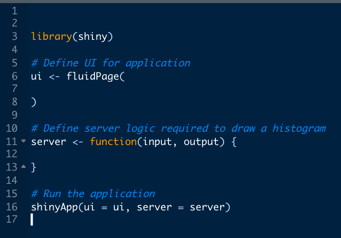